# Dose Finding, Efficacy Evaluation, and Why Programs Fail Late

Naim Rashid, PhD

Department of Biostatistics · Lineberger Comprehensive Cancer Center · UNC

## The first end is that phase III comes in weaker than planned

82 of 143 primary or coprimary survival endpoints, across 111 phase III oncology trials, had observed hazard ratios weaker than those assumed in the power calculations<sup>1</sup>.

## The second end is that dose questions outlive approval

24 dose-optimization postmarketing requirements were issued for 21 of 138 newly approved oncology drugs. Among requirements that had resolved, the median time from issuance to fulfillment or release was 6 years<sup>2</sup>.

Our work identifies one mechanism by which early decisions can create problems that surface later.

## The thesis

We have been treating dose finding, phase II efficacy evaluation, and confirmation as three separate statistical problems.

Our results identify a **mechanism** by which optimizing those stages separately produces problems that only become visible later.

Weaker-than-expected confirmatory efficacy. Late-stage failure. Dose questions that survive into the post-approval setting.

## What I am not arguing

- **Not** that poor dose finding explains phase III failure.
- **Not** that every phase boundary is unnecessary.
- **Not** that simulation itself is inadequate.

What I am arguing is narrower. Conventional development fixes architecture and tuning **before** asking which decisions and which evidence the final claim actually requires.

## How a drug-development program usually works

**Choose a dose**Which dose should move forward?

→

**Look for an efficacy signal**Is it promising enough to continue?

→

**Confirm efficacy**Can we establish that it works?

→

**Approval**The dose question does not always end here.

**Phase boundary.** Where one development stage ends and the next begins.

Each transition fixes decisions and changes what evidence is still available later.

# If a design’s name does not determine its behaviour, what does?

Question 1 of 4

## What did we actually simulate?

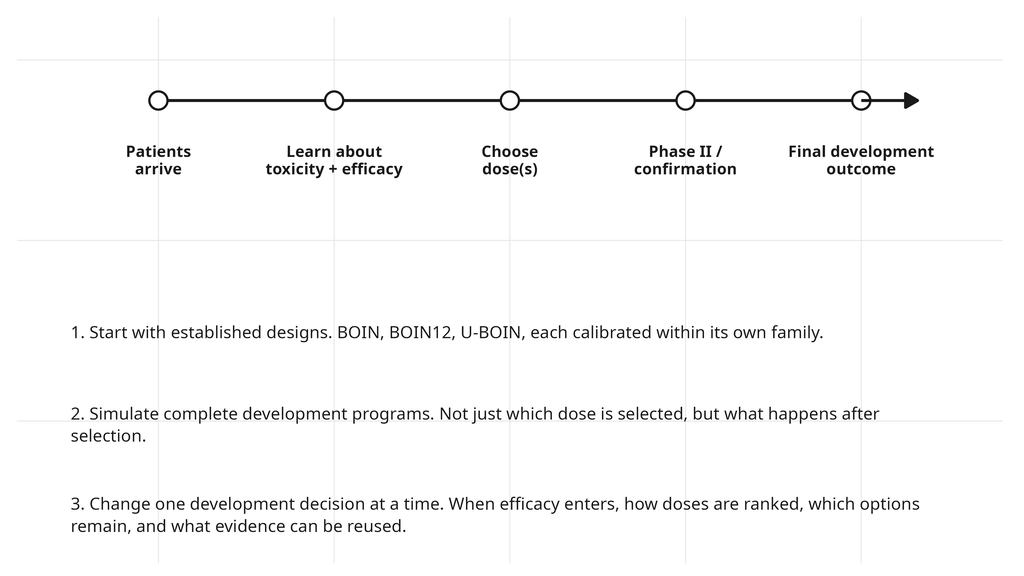

## Two questions, two levels of evaluation

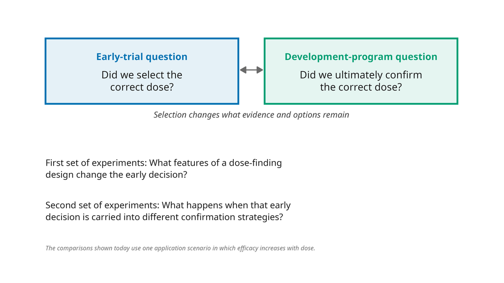

## What the design never knows

**Clinical scenario.** An assumed truth about the drug, the true toxicity and efficacy probability at every dose.

**Correct dose.** The dose with the best true benefit-risk tradeoff. Known to the simulation because the scenario specifies it. Never known to the design.

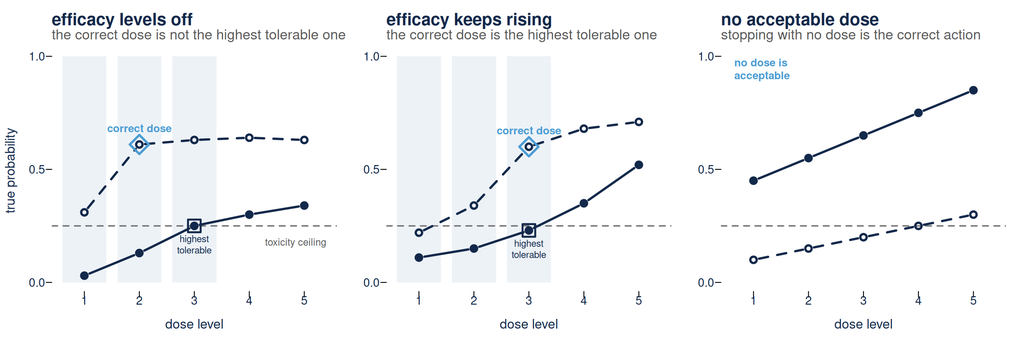

The scenarios the calibration ran on, drawn from the frozen definitions rather than redrawn by hand. Solid line and filled circles, true toxicity. Dashed line and open circles, true efficacy. Shaded, the acceptable doses.

## What calibrated means here

**Calibrated.** Tuning parameters and sample size searched against prespecified operating requirements. A candidate is then locked and independently re-verified on a fresh simulation stream. **The verdict is three-valued**, feasible, infeasible, or unresolved, and the next question is about why.

**Design strategy.** A design family, BOIN, BOIN12 or U-BOIN, together with its calibrated settings.

## How to read the next result

**What changes?** Ranking rule versus evidence summary, one component at a time.

**Why?** If behavior changes when a component changes, the design label is too coarse.

**Readout.** Change in correct-dose selection on the same simulated patients.

## What a design does matters more than its name

We swapped how doses are ranked, then how the data are summarized, one at a time.

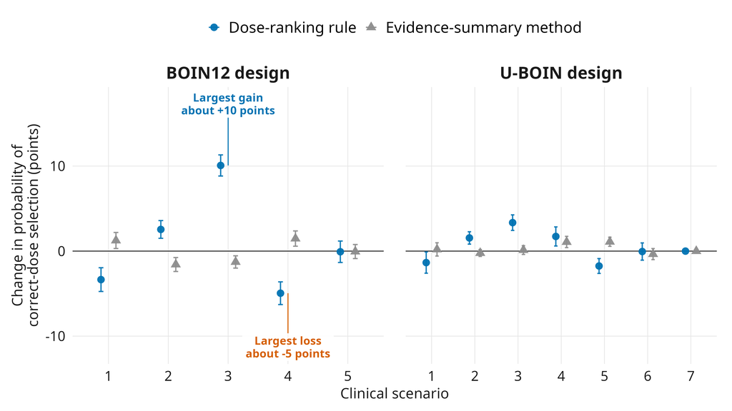

## How to read the next result

**What changes?** Nothing. This one measures a property every variant shares.

**Why?** If the trial can permanently remove the best dose, no ranking rule can recover it.

**Readout.** How often the true best dose is eliminated before selection.

## Some early mistakes cannot be repaired later

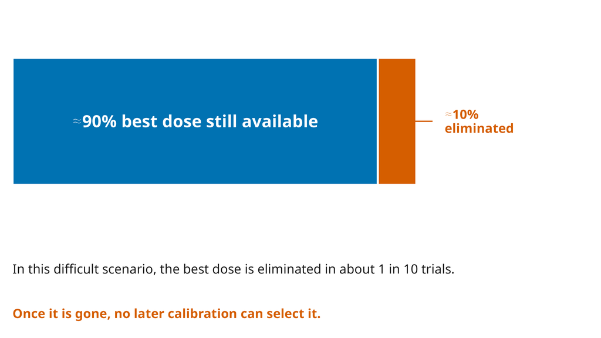

## What Question 1 establishes

Performance is a property of components and context, not of a design’s name.

Which raises the next question.

**How would you establish that any particular implementation is good enough?**

# What would it take to establish that a design meets its requirements?

Question 2 of 4

## The standard evaluation is a simulation table

For each of several scenarios it reports the probability of selecting each dose, the expected sample size, and the distribution of patients across doses.

That table is informative and it is what reviewers are accustomed to reading.

It reports quantities. It does not evaluate them against requirements.

Nor does it report what was not tried.

## What the table does not tell you

- **What value was required.** A reader sees the target selected in roughly half of trials. Required is not stated.
- **What else was available.** The tuning parameters define a space of alternatives. The table describes one point in it.

## The table also cannot show its own optimism

**Whether the number is optimism.** When the same simulations tune and report the design, a favourable number carries optimism the table cannot show.

So the question becomes: what evidence would actually **establish** that a design meets its requirements?

## Search nominates. Verification decides.

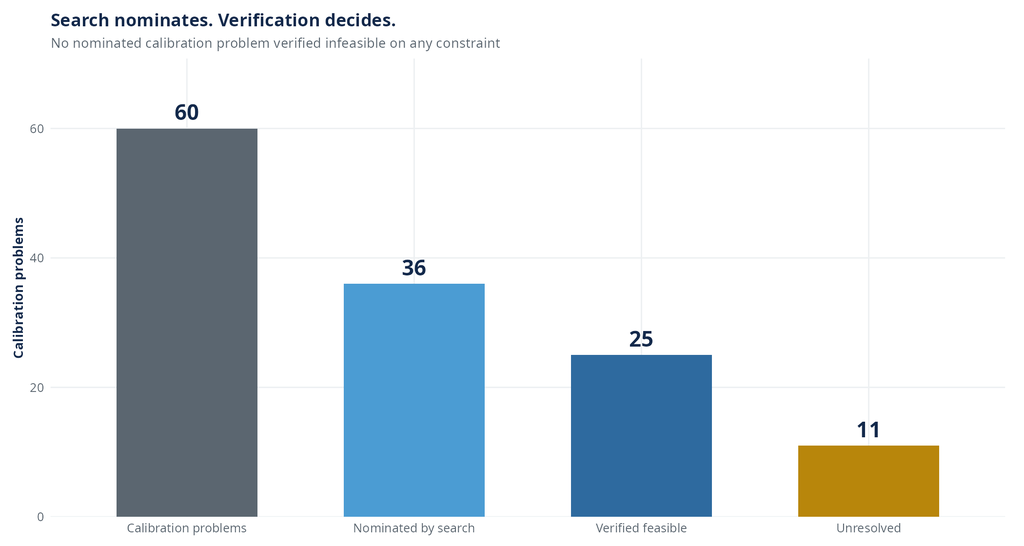

## The distance is the framework working

The distance between what search nominates and what verification establishes is the framework operating as specified, not a loss.

Search selects on **point estimates**. Verification decides on an **interval**.

## Unresolved is neither established nor refuted

A nominated candidate whose remaining uncertainty still crosses the requirement is neither established feasible nor refuted on the evidence collected.

Reporting it as feasible would be exactly the selection-induced optimism the procedure exists to prevent.

## Every verdict is three-valued

**Verified feasible**Evidence clears every prespecified requirement on the situations we chose in advance to test.

**Unresolved**The interval still straddles at least one requirement. Not almost feasible. Not failure.

**Verified infeasible**Evidence establishes that at least one requirement is missed.

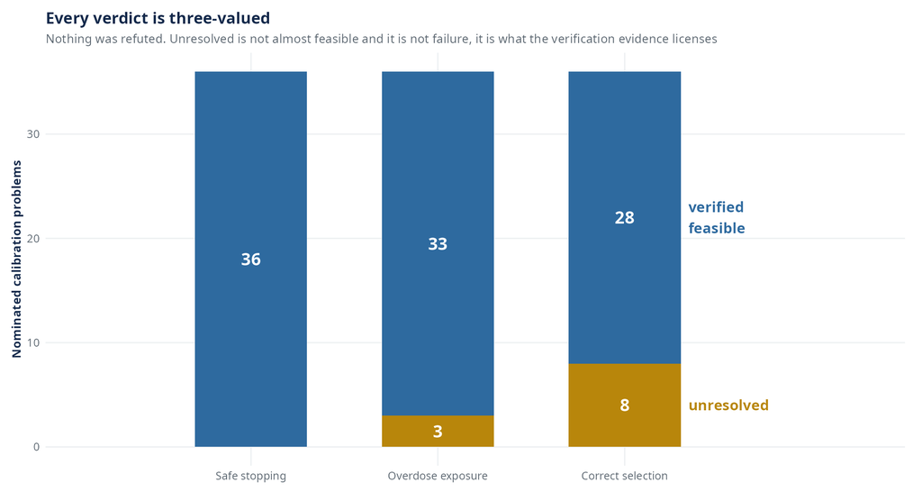

Actual nominated designs occupied the feasible and unresolved states. None was refuted by verification.

## Feasibility is not uniform and that is informative

We searched the same kinds of designs over the same ranges. What changed was what counted as the correct dose and which situations the design had to handle.

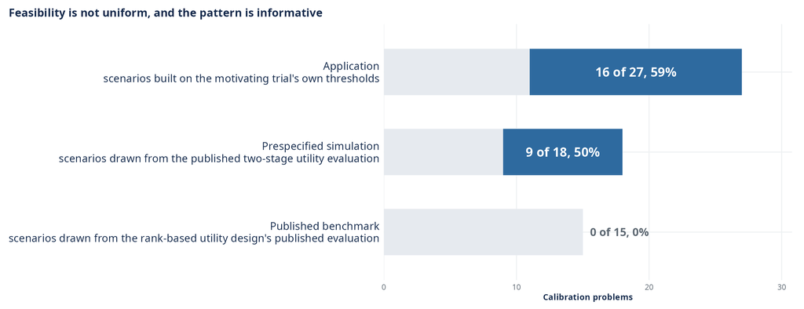

We offer **no mechanism** for the study that establishes none. The campaign as run does not isolate one.

## A verification verdict is conditional on the situations we chose in advance to test

And that conditionality is a finding rather than a caveat.

Feasibility varied materially across sets of situations chosen in advance at a **fixed** search domain.

Locked designs re-scored on further scientifically plausible scenarios could cross constrained safety limits.

## What that conditionality obliges us to publish

Verification on a prespecified scenario set does not establish robustness outside it. This is why the calibration specification is frozen and published with the design.

## What a trial team receives

Design familytwo-stage utility

Maximum sample size27 patients, cohorts of 4

Starting doseLevel 3

Per-dose accrual cap12 patients

Verification verdict Verified feasible 5% error control across the 3 requirements checked together

Tuning vector10 calibrated settings supplied with the protocol

This goes into the protocol, not just into the optimization code.

## What a team does not receive is a guarantee

The verdict is a statement about **the scenarios the specification declared**, at the stated error level, for **the locked design**.

It is not a statement about the design family.

It is not a statement about scenarios outside the declared set.

It is not a statement about a wider range of designs than the one we searched.

# Does the metric we optimize early match what the program needs?

Question 3 of 4

## How to read the next result

**What changes?** Nothing about the designs. Only how we score them.

**Why?** Selecting the correct dose and ending development at the correct dose are different questions.

**Readout.** The two rankings, compared against each other.

## The nine analysis cases behind the next result

**And the standard applies to us.**

- We fixed these **nine analysis cases** before asking the downstream question.
- We later corrected how the simultaneous verification requirements were counted. Under that corrected rule, **seven remain verified feasible** and **two are unresolved**.
- We keep all nine, because dropping two after seeing the downstream results would change the analysis set after the fact.

## Locally best need not be globally best

A strategy can score better at dose selection and worse after confirmation.

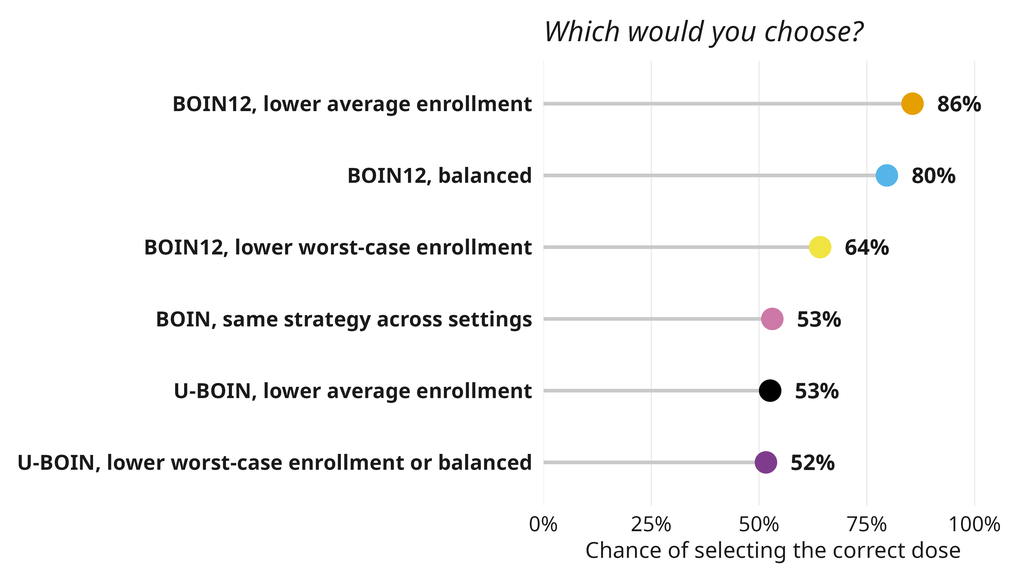

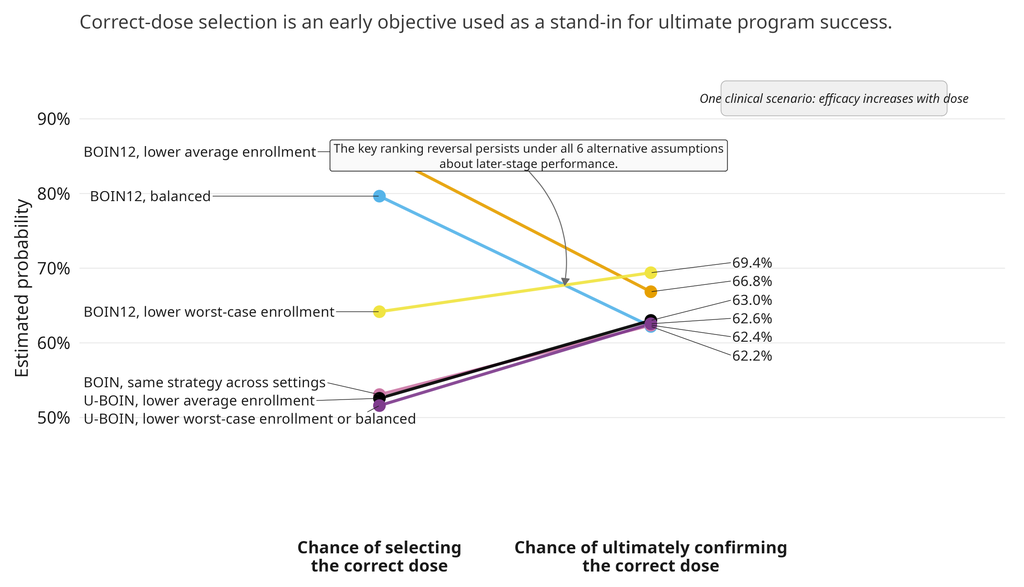

The ordering is the claim here. The small vertical gaps are not interpreted as effect sizes.

## How to read the next result

**What changes?** How dose finding ends. The correct dose, the neighbouring dose, or no dose.

**Why?** Correct-selection probability scores the last two identically. Both are simply wrong.

**Readout.** What each ending is worth to the rest of the program.

## Why correct-dose selection is not the same as program success

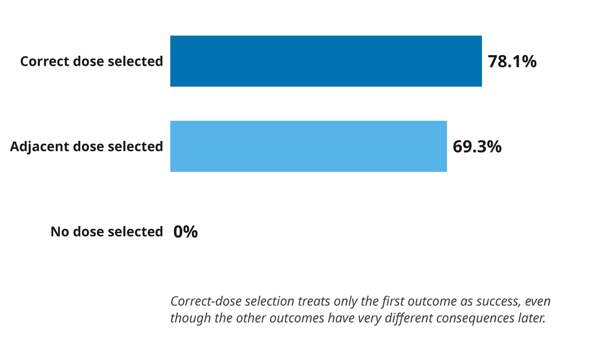

## Only one design family was eligible on the second geometry

That result is established on **one** truth. We repeated the question under a second response geometry, where efficacy plateaus instead of rising toward the target.

Only one design family produced enough eligible strategies to compare there. The families that carried the original inversion were not eligible on that geometry.

## The second geometry bounds this result

Within the eligible set, **the rank reversal did not recur**.

So the second geometry does not confirm the discordance result. It bounds it.

# What does a phase boundary actually decide?

Question 4 of 4

## A phase boundary determines what information survives

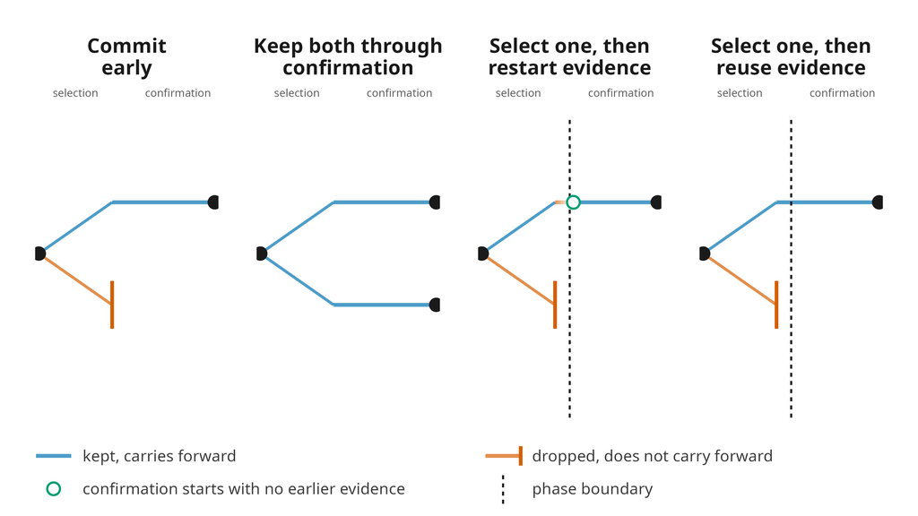

**Four strategies.** Commit early. Keep both through confirmation. Select one, then restart evidence. Select one, then reuse evidence.

## How to read the next result

**What changes?** Only what the program does after dose selection. The selections themselves are identical.

**Why?** Project Optimus, FDA’s dose-optimization initiative, encourages sponsors to compare more than one dose later in development.

**Readout.** Whether the correct final dose is supported after confirmation.

## What changes across geometries

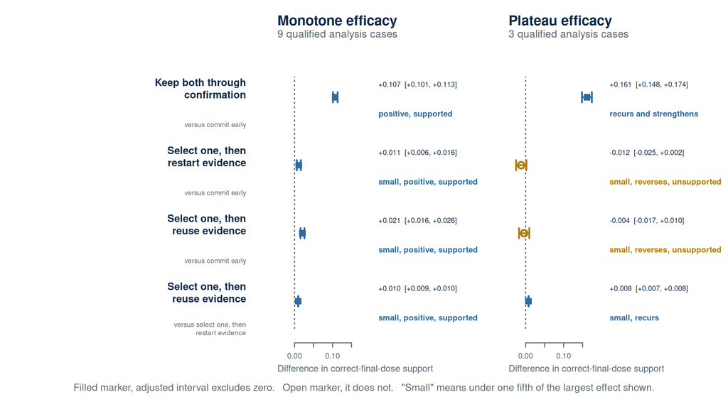

## What the geometry does to the mechanism

The mechanism used to resolve retained uncertainty has to match the shape of how efficacy changes across doses.

Using response data to choose between the two doses helps when efficacy separates the carried doses. When efficacy is flat across them, it no longer resolves the decision and can reverse direction.

## What actually transfers

So the transferable lesson is not “retain two doses”. It is retain uncertainty in a form the next evidence can actually resolve.

## Some uncertainty can be bought back. Some information is gone.

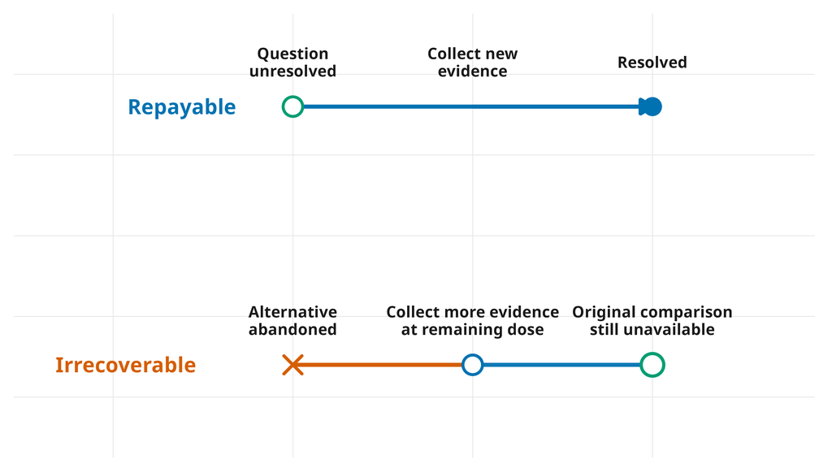

## Sotorasib bought its dose answer after approval

An approved lung-cancer drug whose 960 mg dose was compared against 240 mg only after approval. The original dose was not shown to be wrong. The dose question simply stayed open.

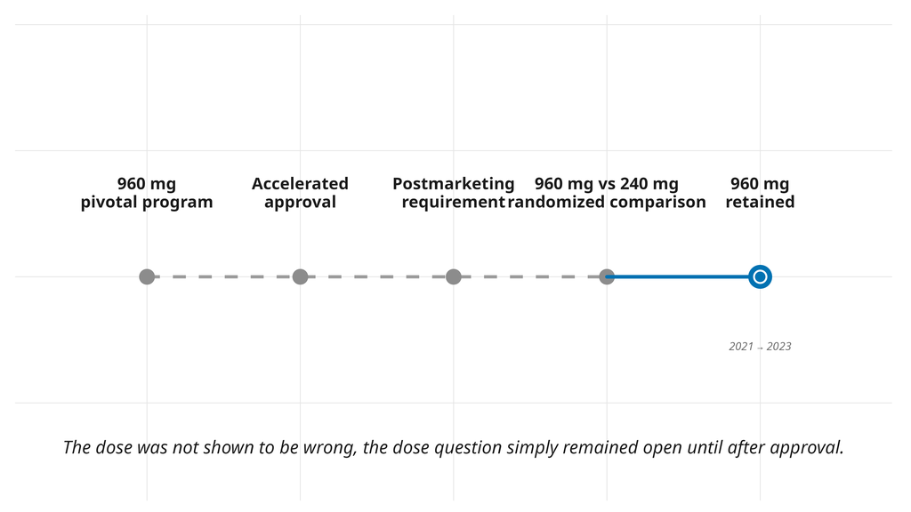

## How to read the next result

**What changes?** Every strategy now gets the same patient budget.

**Why?** The obvious objection is that *keep both through confirmation* only wins because it spends more patients.

**Readout.** What each strategy can still achieve on that budget.

## Preserving dose options has a cost

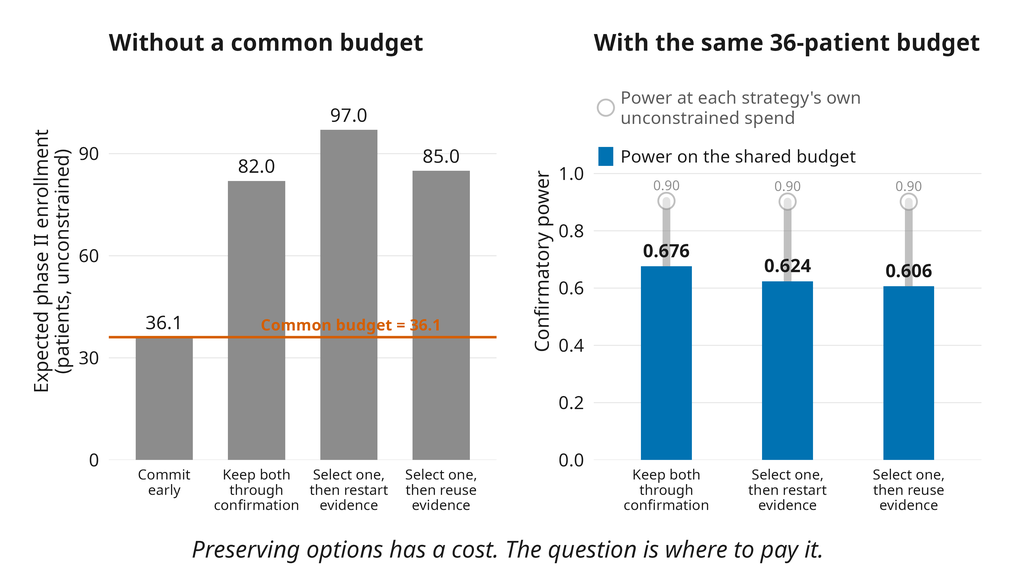

## The systems hypothesis

Clinical development has been optimized **locally** while its errors propagate **globally**.

We have methods for optimizing individual trials, and even linked stages. We have not calibrated the full sequence around what early decisions leave later development able, and required, to prove.

A phase III analysis can have perfectly valid false-positive control while the development program has already failed scientifically.

Failed scientifically means the remaining program can no longer generate the evidence the final claim needs.

## Where this leaves us

We have been treating dose finding, phase II efficacy evaluation, and confirmation as three separate statistical problems.

They are not separate. A dose-finding design’s output is a dose **and the evidence and options it leaves behind**, and that state determines what the rest of development is able, and required, to prove.

## What to do differently

Calibrate the design. Decompose what drives it. Then follow those components through the development program.

## Acknowledgments

**Clinical collaborators**

**Statistical working group and lab**

**Funding**

NCI P50-CA257911 (UNC SToP SPORE)

ARPA-H 140D042590009

DOD HT9425241103100121

NCI U01-CA274298

## References

1.

Sara J. Lamp, Gina L. Mazza. Expected vs observed effect sizes for survival endpoints in phase 3 oncology trials. Journal of the National Cancer Institute. 2025;117(9):1938–41. doi:10.1093/jnci/djaf161

2.

Brian Heiss, Lu Pan, Abebe Akalu, Jonathon Vallejo, James Cheng, Pedro Balcazar, Nam Atiqur Rahman, Stacy Shifflett Shord, Mirat Shah, Richard Pazdur, Marc Theoret. Dosage optimization in drug development. An FDA Project Optimus analysis of postmarketing requirements issued to repair the cracks. In: Journal of clinical oncology. 2023. p. 1598. doi:10.1200/JCO.2023.41.16_suppl.1598